Researcher Track · Molecular Evolution & Comparative Genomics

# One coupled pigment–hormone network, read three ways: selection across primate origins of dichromatism, human disease architecture, and pharmacology

~15

independent phenotypic origins

4

clades with genomic power for selection tests

9 / 17

BH-significant hits pass QC

238

species scored for the trait

HyPhy RELAX (K>1 intensified / K<1 relaxed), per-gene Benjamini–Hochberg correction, QC gate on alignment/tree quality. Companion aBSREL and RERconverge layers. All primate values below are from the v3-certified run.

Design

## The unit of analysis is the independent origin, not the dichromatic species

Sexual dichromatism was scored across a 238-species primate table (9 `complete`, 15 `partial`, 93 monochromatic among genomically usable taxa). Pooling all 24 dichromatic tips into one foreground for a selection test presupposes a shared genetic architecture — the very question under test, and it lets large radiations dominate a naive count.

Ancestral-state reconstruction across the full 238-species tree indicates sexual dichromatism arose independently **~15 times** in the primate radiation, and is lost roughly **9× more readily than it is gained** — a labile trait, reachable and dischargeable through several routes rather than fixed by one canonical switch. That lability is a first line of evidence for the coupled-network reading developed below: a trait gated by multiple accessible remodeling points (pigment module, hormone module) should be easy to lose and easy to re-derive, exactly the asymmetry observed.

The genome-level selection test (HyPhy RELAX) does not have equal power across all ~15 origins. It is powered on the **4 clades with usable genomic sampling**: Lemuridae/*Eulemur*, Cebidae, Hylobatidae (gibbons), and Cercopithecidae. The ~15-origin count describes phenotype mapping on the full tree; the 4-clade count is the statistical-power caveat for everything that follows.

**Limitation.** Per-origin RELAX is adequately powered only for the 3 multi-tip origins (≥2 tips) among the 4 tested clades; the remaining origin is covered by aBSREL and RERconverge, not treated as missing data, but the layers are not interchangeable in power.

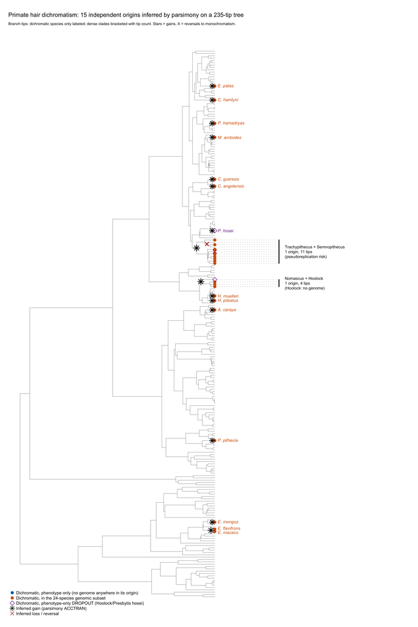

**Fig. 1.** Primate phylogeny with dichromatic tips and independent origins marked. The foreground for selection inference is defined at the level of the origin, not the species count.

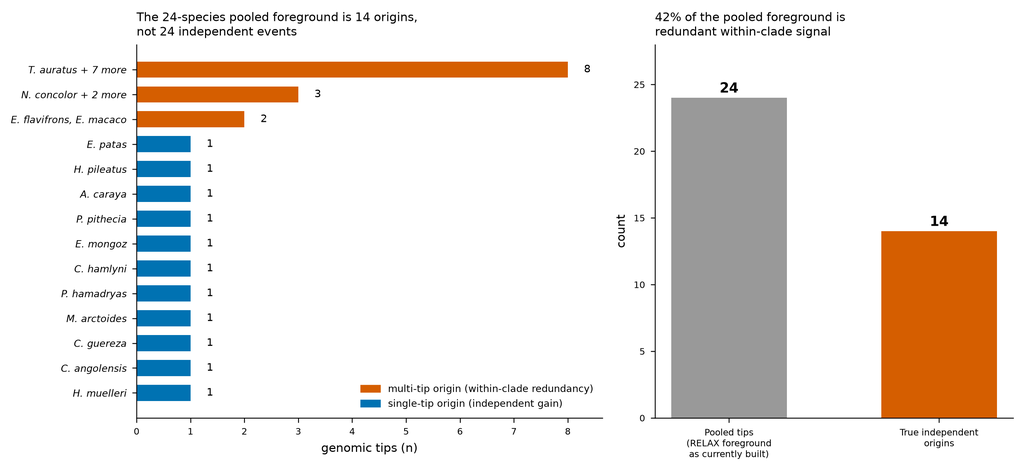

**Fig. 2.** The pooling problem, quantified: naive pooling of all dichromatic tips is dominated by a small number of species-rich radiations, inflating apparent replication of the trait.

### Why this matters for the inference

A trait that evolved once and radiated looks, in a species-level tally, like many independent replicates. Counting at the origin level is the more conservative and defensible framing when the claim on the table is *convergent, origin-specific* selection.

**Stated plainly.** Selection inference below is powered on 4 clades, a small n for a convergence claim, out of ~15 phenotypic origins. The result describes what is certified in those 4, not a general law of primate dichromatism.

Result — The Flagship (Reading 1: Deep Time)

## The certified signal is polygenic, and splits across two modules

Of 17 genes reaching BH significance on the dichromatic foreground (12 intensified, K>1; 5 relaxed, K<1), **9 pass the QC gate** (alignment gap fraction, K bounds, n<sub>foreground</sub>≥3, tree length, aln_ref_ratio ∈ [0.8, 1.2]) — 8 intensification hits plus the one certified relaxation hit, SHBG. The 8 rejected genes — including two biologically attractive candidates, POMC and TYR — are alignment artifacts (aln_ref_ratio 0.68 / 0.65, truncated extraction) and are not reported as hits.

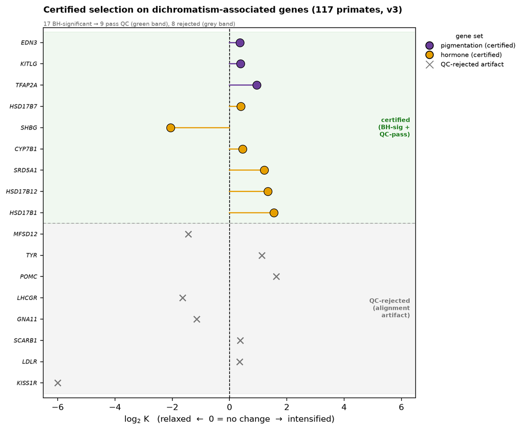

**Fig. 3.** log₂K by gene for all BH-significant tests on the dichromatic foreground (117 primates, v3). Green band: QC-pass, certified. Grey band: QC-rejected, not reported as hits. Color = gene set (purple = pigmentation, orange = hormone).

#### Pigmentation module (melanoblast development)

| Gene | K | p<sub>BH</sub> | QC |
| --- | --- | --- | --- |
| *TFAP2A* | 1.93 | 1×10<sup>−4</sup> | clean |
| *KITLG* | 1.30 | 1.5×10<sup>−3</sup> | clean |
| *EDN3* | 1.28 | 1.5×10<sup>−3</sup> | Tier-B |

#### Hormone module (steroid-metabolism enzymes)

| Gene | K | p<sub>BH</sub> | QC |
| --- | --- | --- | --- |
| *HSD17B1* | 2.93 | <1×10<sup>−3</sup> | clean |
| *HSD17B12* | 2.52 | <1×10<sup>−3</sup> | clean |
| *CYP7B1* | 1.37 | 7.8×10<sup>−3</sup> | clean |
| *HSD17B7* | 1.32 | 4.0×10<sup>−2</sup> | clean |
| *SRD5A1* | 2.32 | <1×10<sup>−3</sup> | Tier-B |

#### The one relaxation hit

| Gene | K | p<sub>BH</sub> | QC |
| --- | --- | --- | --- |
| *SHBG* | 0.24 | 2.9×10<sup>−2</sup> | relaxed |

A hormone *carrier/transport* gene, not an enzyme — the single significant relaxation signal, and the only certified hit in that direction.

**Limitation.** EDN3 and SRD5A1 carry a QC flag (branch-length / gap fraction, respectively) and are reported as Tier-B, rescue-pending — not withheld, but not on the same footing as the 7 fully clean hits. POMC (K=3.1) and TYR (K=2.2) fail alignment QC outright and are not certified results; a denser genome sample is the stated path to re-testing them.

Result — Architecture and the cross-taxon comparison

## Two coupled modules, and the single-gene bird switch is absent

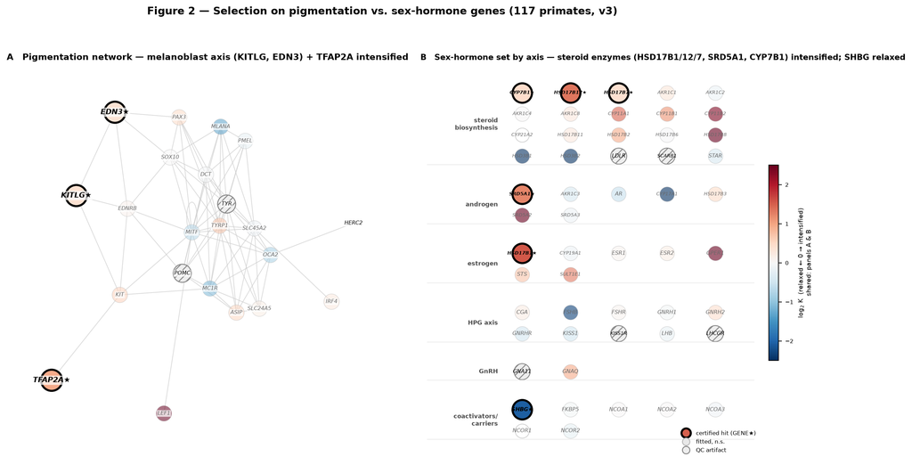

**Fig. 4.** The pigmentation module (physically connected, converging on SOX10/MITF) and the hormone gene set (steroid-metabolism enzymes, by axis), plotted on one intensification scale.

The pigmentation hits are not an arbitrary gene list: TFAP2A, KITLG, and EDN3 sit on one connected melanoblast-development signalling path converging on SOX10/MITF. The hormone hits are steroid-metabolism *enzymes* (HSD17B1/7/12, CYP7B1, SRD5A1) that interconvert active androgens and estrogens — a biologically coherent set for a trait that is, by definition, sex-dimorphic.

**Limitation.** A formal set-level contrast of pigmentation vs. hormone intensification is **not significant** (100k-permutation label-swap p≈0.47; Wilcoxon p≈0.11). The finding is about *which genes, in which origins* — not that one module dominates the other. Neither "hormones beat pigment" nor the reverse is supported.

### MC1R: the cross-taxon divergence, stated carefully

In galliform birds, sexual dichromatism tracks intensified selection at a single gene, MC1R (Nadeau et al. 2007, *Proc. R. Soc. B*, doi:10.1098/rspb.2007.0174). In this primate dataset MC1R is QC-clean but shows only **weak, non-significant relaxation**: K=0.45, p=0.043, **p<sub>BH</sub>=0.144**.

The correct statement is: the bird's single-gene switch is absent in primates. It is *not* correct to say MC1R is under significant relaxation here — it does not clear multiple-testing correction.

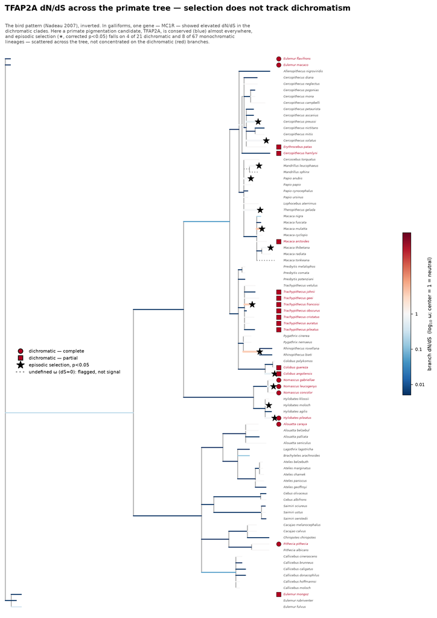

Second reading — Human disease

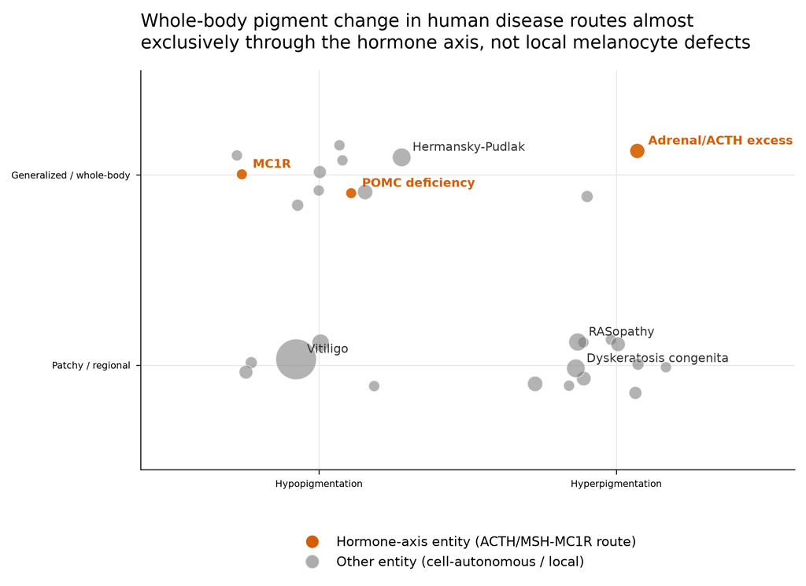

**Fig. 6.** Human monogenic and syndromic pigmentation disorders (n=200 gene–disease entries), classified by direction of pigment change (hypo/hyperpigmentation) and spatial extent (generalized/whole-body vs. patchy/regional). Marker size scales with the number of genes per entity; orange marks the systemic ACTH/MSH→MC1R axis.

Classifying 200 gene–disease entries in the human pigmentation-disorder literature by two independent axes — direction of change and spatial extent — separates two very different failure modes. Most entities, in either direction, are **patchy or regional**: cell-autonomous melanocyte defects (biogenesis, transport, migration, immune destruction) that affect the skin locally.

The **generalized, whole-body** quadrant is different in kind. On the hyperpigmentation side it is populated almost entirely by **systemic ACTH/MSH excess** (CYP11A1, MC2R, MRAP, NR0B1, STAR) — adrenal disease that floods the melanocortin axis and cross-activates MC1R everywhere at once. Its endocrine mirror is POMC deficiency: loss of the MSH ligand itself, generalized hypopigmentation (red hair, in the classic phenotype).

Third reading — Pharmacology

## The convergence node is a real drug target, and an agonist there moves the whole-body phenotype

The disease quadrant identifies the melanocortin axis as the whole-body dial. Two independent hormone receptor systems feed the same intracellular switch in melanocytes: the melanocortin receptor **MC1R** (activated by α-MSH/ACTH) and the estrogen receptor **GPER1**, both converging on **cAMP → CREB → MITF**, the transcriptional node that sits immediately downstream of the melanoblast-development module identified in the primate result (Fig. 4).

**Melanotan**, a synthetic α-MSH analog and melanocortin-receptor agonist, is the pharmacological demonstration that this node is not a hypothetical wiring diagram: agonizing MC1R with a diffusible peptide is sufficient to darken pigment output body-wide, in real time, in an otherwise unmanipulated adult — the same generalized-hyperpigmentation phenotype that systemic ACTH excess produces endocrinologically in Fig. 6.

**Scope note.** This is evidence that the melanocortin→cAMP/CREB/MITF axis is causally sufficient to shift pigmentation in humans. It does not test, and should not be read as testing, whether the specific primate-certified genes (TFAP2A, KITLG, HSD17B1, etc.) are themselves under selection or pharmacologically targeted in humans; the link is at the level of pathway architecture, independently supported on each side.

[figure not shown]

**Fig. 7.** Schematic of the melanocortin (MC1R) and estrogen (GPER1) axes converging on cAMP→CREB→MITF in melanocytes. Established pathway architecture, shown here as a design schematic, not a fitted analysis figure; Melanotan is the pharmacological agonist at MC1R.

Synthesis

## Three readings of one coupled network

The pigmentation module and the sex-hormone axis are not two separate stories that happen to share a project. They are one coupled biological object — melanocyte-development signalling wired to hormone input at cAMP→CREB→MITF — and the evidence above reads that same object at three different timescales and levels of resolution.

#### Reading 1

Deep time

Dichromatism arose independently ~15 times and is lost ~9× more readily than gained — a labile trait. Selection acts on *both* sides of the coupling — the melanoblast-development module (TFAP2A/KITLG/EDN3) and the steroid-metabolism enzymes (HSD17B1/7/12, CYP7B1, SRD5A1) — in the 4 clades where genomic sampling gives the test power.

#### Reading 3

Pharmacology

Agonizing the melanocortin receptor with Melanotan reproduces that whole-body effect on demand, confirming that MC1R→cAMP→CREB→MITF is causally sufficient, not merely correlated with pigment output.

Each reading is independent evidence, obtained by a different method (molecular evolution, disease-entity classification, pharmacology), converging on the same architectural claim: **pigmentation output in this network is not autonomous to the melanocyte — it is gated by hormone input, and that gate is where a disproportionate share of the certified selection, the disease burden, and the drug action all sit.**

**What is not claimed.** The three readings support one architecture, not one mechanism. The primate-certified genes are not shown to be selected, mutated, or pharmacologically targeted in the human cases; each reading stands on its own evidence and the synthesis is at the level of network topology, stated explicitly rather than implied.

Deep-time reading, quantified

## The trait is heritable and labile, but selection module and dichromatism do not co-evolve

The three claims above — heritable trait, labile trait, coupled network — are testable with the same phylogenetic-comparative tools Opie, Atkinson & Shultz applied to primate mating systems (*Commun Integr Biol* 2012, doi:10.4161/cib.20821). We replicate their **method**, not their trait.

**Phylogenetic signal.** Pagel's λ = **0.65** for hair dichromatism (likelihood-ratio p < 10<sup>−6</sup>): closely related species resemble each other in the trait, as a heritable character should. (Opie reported λ ≈ 0.996 for mating systems.)

**Lability.** An asymmetric-rates model is favoured over equal rates by ΔAIC = **19.8**; the loss rate exceeds the gain rate **9.1×** — dichromatism is lost far more readily than gained.

**Correlated evolution.** Does a lineage being under selection in the pigment (or hormone) module co-evolve with its being dichromatic? Fitting Pagel's *Discrete* dependent-vs-independent model (`phytools::fitPagel`, the maximum-likelihood analog of the Opie BayesTraits test) on the 102-tip genomic panel, the **independent** model is preferred for both modules (pigment ΔAIC 3.7, p = 0.37; hormone ΔAIC 5.7, p = 0.68).

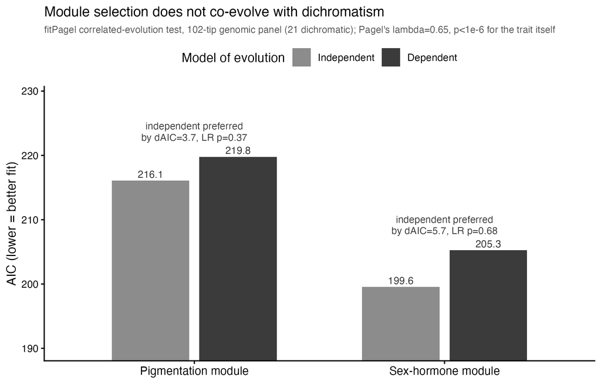

Correlated-evolution test. For both modules the independent-evolution model fits better (lower AIC) than a model where module selection and dichromatism depend on each other. Frozen, replay-verified notebook: `comparative-genomics/analysis/coevolution_test/`.

Limitations, together in one place

## What this result does and does not support

| Claim | Basis | Explicit limitation |
| --- | --- | --- |
| Architecture is polygenic, split pigment/hormone | 9/17 BH-sig hits pass QC across both modules | Set-level contrast is not significant (p≈0.47 permutation, p≈0.11 Wilcoxon) |
| MC1R is not the primate hit | K=0.45, p=0.043 | p<sub>BH</sub>=0.144 — does not clear correction; state as absence, not as significant relaxation |
| ~15 independent phenotypic origins (ancestral-state reconstruction, full tree) | 238-species tree, full ancestral-state reconstruction | Describes phenotype mapping, not selection-test power; the genome-level RELAX test is powered on only 4 of these clades, and only 3 of those 4 are multi-tip / adequately powered per-origin |
| POMC / TYR as candidates | Nominally large K (3.1 / 2.2) | Fail alignment QC (aln_ref_ratio 0.68 / 0.65); not certified; flagged as a future direction requiring denser sampling |
| EDN3 / SRD5A1 | BH-significant, in-module | QC flags (branch length / gap fraction); reported as Tier-B, rescue-pending |
| Human disease quadrant | 200-entity classification, two independent axes | Descriptive catalog, not a statistical test; supports architecture, not prevalence or effect size |
| Melanotan / MC1R–GPER1→MITF panel | Established pathway biology + marketed agonist | Architectural analogy to the primate module, not evidence that the primate-certified genes are themselves selected or targeted in humans |

Three questions

## Rubric

What did Claude Science help us do?

Ran and QC-gated a clade-wide, per-origin HyPhy RELAX screen across 238 scored primate species and their genomic subset, cross-checked against aBSREL/RERconverge, classified 200 human pigmentation-disorder entities along two independent axes, and enforced a defensible unit of analysis (independent origins, not pooled species) before any gene was called a hit.

How are we closer to a finding?

We can now state, with correction and QC applied, which genes are certified versus artifactual (POMC/TYR excluded), that the primate signal is polygenic and module-split rather than single-gene, that the canonical bird MC1R mechanism does not replicate in primates, and that the same pigment–hormone coupling this implies is independently visible in human disease structure and reproducible with a marketed pharmacological agonist — three separate lines converging on one network claim.

What is the flagship?

The first clade-wide, per-independent-origin selection test of the genomic architecture of sexual dichromatism in primates, showing that architecture is heterogeneous and polygenic (pigmentation + steroid-metabolism modules) and diverges from the single-gene MC1R model established in birds — read alongside two subordinate, independently-sourced panels (human disease classification, Melanotan pharmacology) showing the same hormone-gated network architecture generalizes beyond the primate selection test.

v3-certified run · HyPhy RELAX + aBSREL + RERconverge · BH correction · QC-gated